# The New York Taxi Dataset

May 28, 2015

## Dataset description

### A wealth of taxi trips

## A few words about this dataset

- [Chris Whong](http://chriswhong.com/open-data/foil_nyc_taxi/) submitted a FOIL (The Freedom of Information Law) request to the New York City Taxi & Limousine Commission (NYCT&L).
- The entire dataset spans 2010-2013 and consists of approximately **700M trips** split into various text files.
- It is a big dataset by public data standards.
  - The [flight delay dataset](http://www.transtats.bts.gov/DL_SelectFields.asp?Table_ID=236&DB_Short_Name=On-Time), normally referenced for out-of-memory calculations, is 100M+ records long.
  - It was an engineering challenge to deal with such a large dataset.
- Structure:
  - Trip dataset
  - Fare dataset
- Very granular: timestamp, longitude and latitude of pickup and dropoff locations.
- The data was relatively clean to begin with, except for a few cases like trips to the North Pole, the middle of the Atlantic Ocean, or that took no time at all.

## What does the data look like?

| fare_amount | surcharge | mta_tax | tip_amount | tolls_amount | total_amount |
| --- | --- | --- | --- | --- | --- |
| 8.5 | 1 | 0.5 | 2 | 0 | 12 |
| 8.5 | 1 | 0.5 | 1.9 | 0 | 11.9 |
| 20.5 | 0 | 0.5 | 4.1 | 0 | 25.1 |
| 7.5 | 0.5 | 0.5 | 1.7 | 0 | 10.2 |
| 11 | 0.5 | 0.5 | 2.4 | 0 | 14.4 |
| 6.5 | 1 | 0.5 | 1.5 | 0 | 9.5 |
| 8.5 | 1 | 0.5 | 1 | 0 | 11 |
| 22 | 0.5 | 0.5 | 0 | 0 | 23 |
| 9 | 0 | 0.5 | 0 | 0 | 9.5 |
| 31.5 | 1 | 0.5 | 0 | 0 | 33 |

| passenger_count | trip_time_in_secs | trip_distance | pickup_longitude | pickup_latitude |
| --- | --- | --- | --- | --- |
| 1 | 622 | 1.2 | -74.003357 | 40.738918 |
| 1 | 600 | 1.35 | -73.98053 | 40.742371 |
| 5 | 840 | 6.87 | -73.955109 | 40.764771 |
| 1 | 498 | 1.3 | -73.993896 | 40.720493 |
| 1 | 946 | 2.3 | -73.977577 | 40.761745 |
| 1 | 420 | 1.17 | -73.995285 | 40.726086 |
| 2 | 499 | 1.8 | -73.985054 | 40.753296 |
| 1 | 1251 | 6.5 | -74.001579 | 40.735909 |
| 1 | 600 | 1.76 | -73.963699 | 40.777119 |
| 1 | 1740 | 9.8 | -74.001999 | 40.715271 |

Or it can be seen on a [map](https://gballardin.shinyapps.io/nytaxiappv2/)

## Trip heatmap

[figure not shown]

## Daily trip load curve

- Similar shape to other human activities (electricity, website visits, etc.)
- 4-6pm dropoff is apparently due to drivers changing for the [evening shift](http://chriswhong.com/wp-content/uploads/2014/03/taxi1.png).

[interactive chart not shown]

## The analysis

### Applying stochastic optimization

## What goal to pursue?

**Passengers**

- **Goal:** go from point A to B at a given point in time.
- **Solution:** compare alternative means of transportation (taxi, subway, bus, bicyle, walking). Include costs and opportunity costs of individual decision makers.
- **Issues:** access to opportunity costs. While one could build a theoretical model, it would be hard to use this dataset to provide evidence-based recommendations.

**City of New York**

- **Goals:** increase revenues (e.g. via 'surcharge': extra fees, such as rush hour and overnight surcharges) and/or allocate congestion more efficiently.
- **Solution:** for example, instead of having a binary rush-hour charge, tune charge to demand curve. Alternatively, create a bid-based system for surcharges.
- **Issues:** continuous-time surcharge can be calculated, but it would be hard to assess its benefits, since we can't observe a counterfactual. One option in the real world would be to run a test (split taxi drives between old and new policy).

## More interesting problem

**Optimal taxi rider routing**

- **Goal:** maximize expected profit. On a given day, define the final place and time where and when to end and back-calculate optimal routing.
- **Solution:** stochastic optimization with [Bellman equation](http://en.wikipedia.org/wiki/Bellman_equation). Optimize (profit) in discrete time steps and work out best place to start the working day.
- **Implementation:**
  - Partition the pickup locations using k-means clustering (step #1 in modeling script).
  - With the classification from above, assign dropoff locations with Support Vector Machines (step #2 in modeling script).
  - Write optimal routing algorithm (step #3 in modeling script).

## Clustering pickup locations

[interactive chart not shown]

## Optimal routing algorithm - 1

I developed **two algorithms**:  
1. One that optimizes routing with constant time windows (e.g. one hour).  
2. One that optimizes routing over length-varying time windows (exactly from one ride to the next).

**Setup**

Input:  
1. 'beg_of_day'. When the working day begins.  
2. 'end_of_day'. When the working day ends.  
3. 'home_cluster'. Which location cluster the taxi driver would like to end the day in.  
4. 'minute_range'. Factor in some tolerance for target end time of each ride.

```r
beg_of_day <- as.POSIXct(strptime('2013-01-17 07:00:00', format = "%Y-%m-%d %H:%M:%S"))
end_of_day <- as.POSIXct(strptime('2013-01-17 10:00:00', format = "%Y-%m-%d %H:%M:%S"))
home_cluster <- 6
minute_range <- 5
```

## Optimal routing algorithm - 2

**Transition matrix**

- Modeled as a [Markov Chain](http://en.wikipedia.org/wiki/Markov_chain)
- Maximise expected payoff given destination cluster: \(\sum _{i}(prob_i * payoff_i)\)
- Derive optimal origin cluster from point above

**Pseudo-code**

Repeat until beginning time is reached:

- If(first iteration):
  - Compute transition matrix
  - Choose origin that maximises expected profit given user-defined destination
  - Write result out
- Else:
  - Compute transition matrix
  - Choose origin that maximises expected profit given pre-calculated destination from previous step
  - Write result out

## Example of optimal solution results

| orig_cluster | dest_cluster | trip_beg_time | trip_end_time | mean_travel_time |
| --- | --- | --- | --- | --- |
| 6 | 6 | 2013-01-17 09:52:40 | 2013-01-17 10:00:00 | 439.9020 |
| 6 | 6 | 2013-01-17 09:46:00 | 2013-01-17 09:52:40 | 399.1525 |
| 6 | 6 | 2013-01-17 09:39:03 | 2013-01-17 09:46:00 | 417.4483 |
| 5 | 6 | 2013-01-17 09:26:06 | 2013-01-17 09:39:03 | 777.4324 |
| 5 | 5 | 2013-01-17 09:17:39 | 2013-01-17 09:26:06 | 506.1071 |
| 5 | 5 | 2013-01-17 09:08:39 | 2013-01-17 09:17:39 | 540.5333 |
| 5 | 5 | 2013-01-17 09:00:42 | 2013-01-17 09:08:39 | 476.8939 |
| 5 | 5 | 2013-01-17 08:52:21 | 2013-01-17 09:00:42 | 501.0169 |

## How does optimal routing look like?

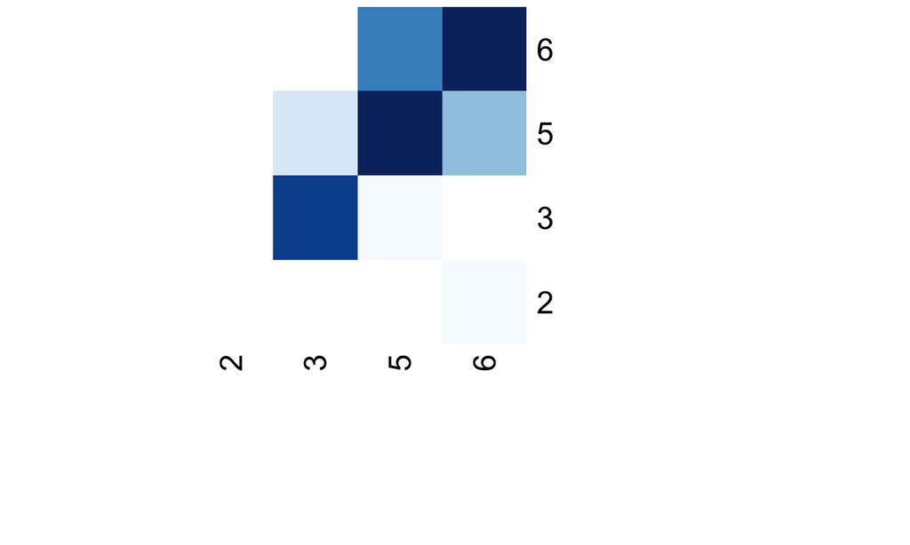

[interactive chart not shown]

## Areas for improvement

**Easy**

- **Do not limit end location (cluster) to the desired one**. Here's how:
  - Calculate distance from end location to any other cluster. Compute cost of driving there.
  - Compute opportunity cost (forgone profit at that time of the day). The data is all there already.
- **Factor in non-running times**:
  - Chosen (meals, breaks)
  - Imposed (idle time)
- **Optimize for profit**, instead of revenues:
  - Calculate marginal ride cost (distance, gasoline price, car efficiency)
  - Taxi drive opportunity cost (from this dataset)

## Areas for improvement

**More difficult**

- **How often to re-optimize?**
  - Not an easy dynamic programming question
  - Some good heuristic may be inferred from the data, but analytical solution is tougher
- **Include risk aversion in the calculations**
  - Do not just maximise profit, but choose the route that gives the optimal {profit, variance(profit)} tradeoff given the taxi driver preferences

## Potential applications

As far as I can tell, [Uber](https://www.uber.com/features) does not disclose information about passenger destination at ping time.

Reasons:

1. Avoid ride 'cherry-picking'.
2. Cover the low end of the market (e.g. $5 rides).

A counter-argument is that freer information leads to a better market allocation.

Intuition:

1. Decrease supply of unprofitable rides ($5 >> $8).
2. Increase supply of profitable rides ($45 >> $40).

Besides there is no point in asking a driver to take on negtive profit rides.

With the appropriate data, which is the case for NYC, my algorithm could help Uber and other drivers make the decision as to whether to accept a ride ex-ante, based on expected profit calculations.

## Code

- Code used to download, clean, analyse, visualize, and present this dataset can be found on [GitHub](https://github.com/gballardin/nytaxi).
- Feel free to peruse, fork, and play with this dataset.

[figure not shown]